# ML Algorithms for classification

Slides – http://bit.ly/2q9NPSU

## Aims of this lesson

- Understand what are decision trees and random forests , how they works, and how to evaluate a DT or a RF model.
- Decision tree is a type of supervised learning algorithm (having a pre-defined target variable) mostly used in classification problems.
- It works for both categorical and continuous input and output variables.
- In this technique, we split the population or sample into two or more homogeneous sets (or sub-populations) based on most significant splitter / differentiator in input variables.

## Decision trees

## Example

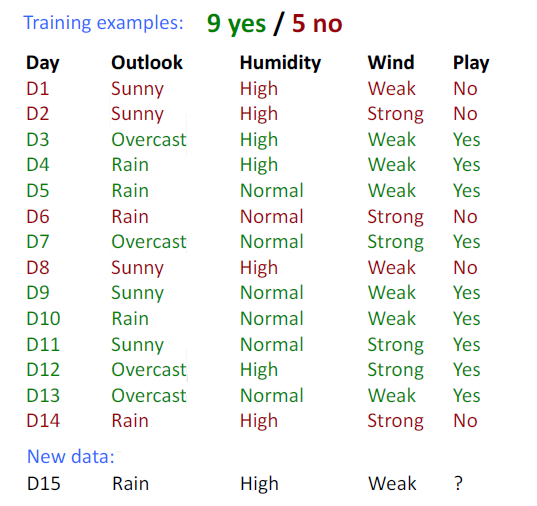

## Example

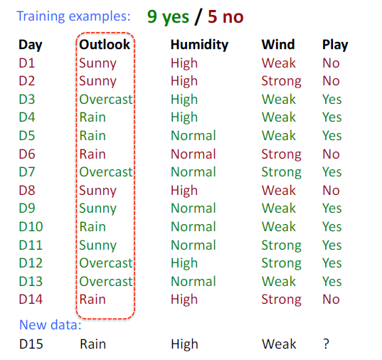

## Example

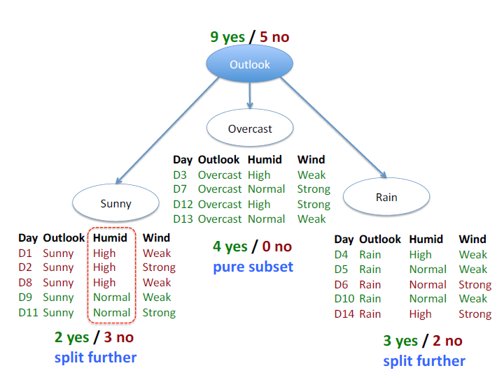

## Example

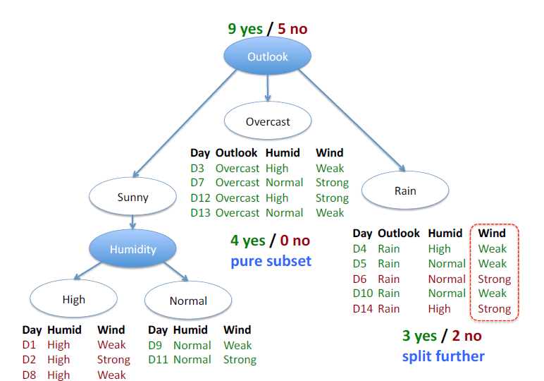

## Example

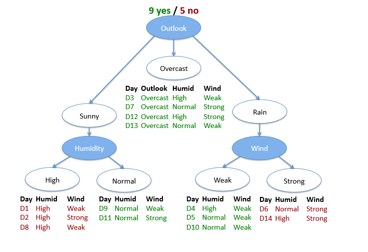

## Example

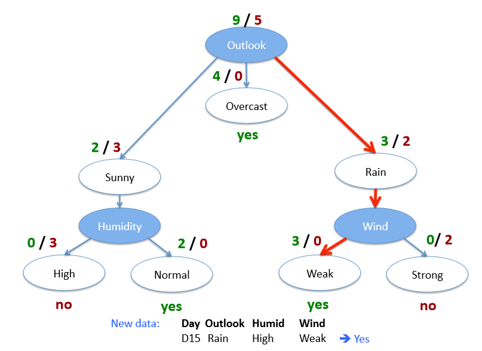

## Types of decision trees

- **Classification decision tree:** Decision trees which have categorical target variable
  - Models suitable for answering questions: Which category(ies)
- **Regression trees:** decision trees that have continuous target variable
  - Models suitable for answering questions: How mach, how many

## Terminology related to decision trees

1. **Root Node:** It represents entire population or sample and this further gets divided into two or more homogeneous sets.
2. **Splitting:** It is a process of dividing a node into two or more sub-nodes.
3. **Decision Node:** When a sub-node splits into further sub-nodes, then it is called decision node.
4. **Leaf/ Terminal Node:** Nodes do not split is called Leaf or Terminal node.
5. **Pruning:** When we remove sub-nodes of a decision node, this process is called pruning. You can say opposite process of splitting.
6. **Branch / Sub-Tree:** A sub section of entire tree is called branch or sub-tree.
7. **Parent and Child Node:** A node, which is divided into sub-nodes is called parent node of sub-nodes where as sub-nodes are the child of parent node.

## Terminology related to decision trees

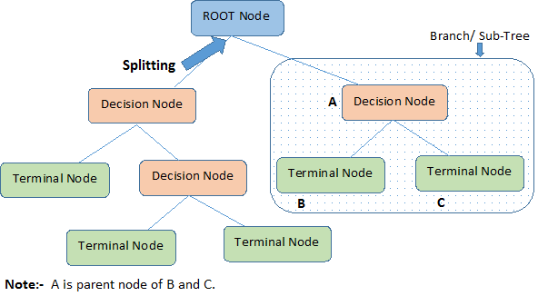

## Advantages & disadvantages

### Advantages

- Easy to Understand:
- Useful in data exploration:
- Less data cleaning required.
- Data type is not a constraint.
- Non parametric method.

### Disadvantages

- Over fitting
- Not fit for continuous variables

## How does a tree decide where to split?

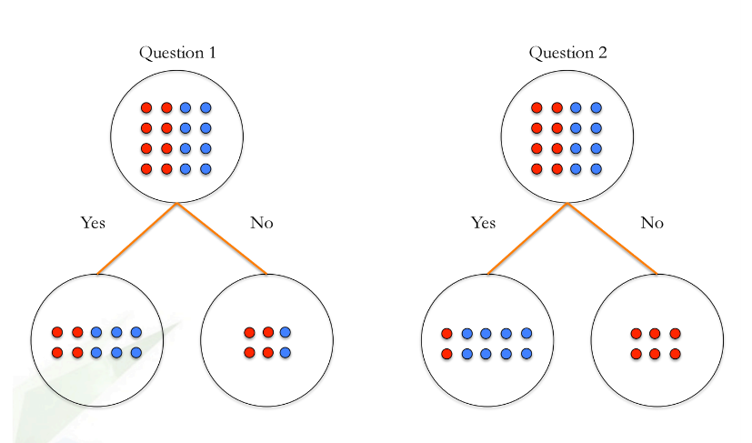

## How does a tree decide where to split?

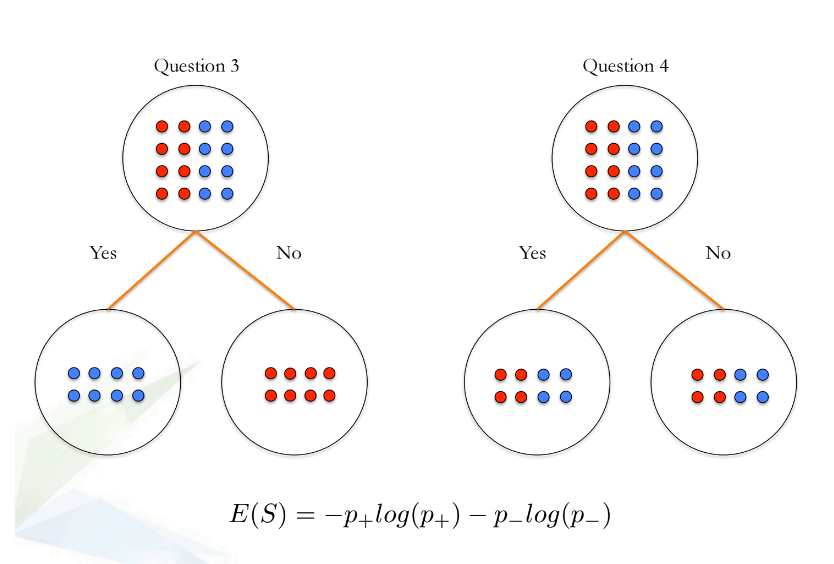

## How does a tree decide where to split?

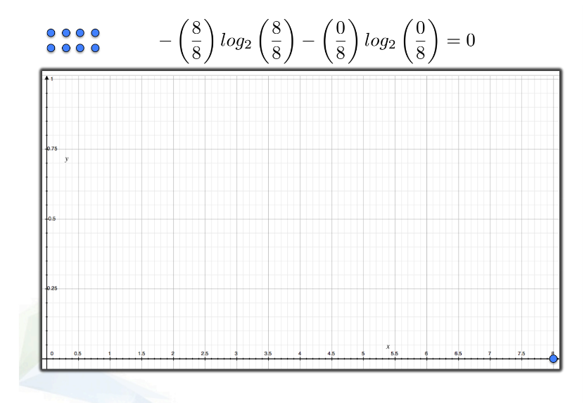

## How does a tree decide where to split?

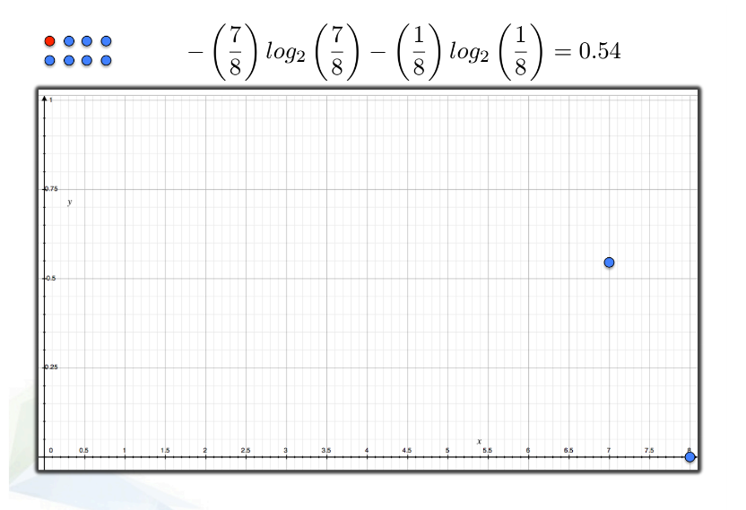

## How does a tree decide where to split?

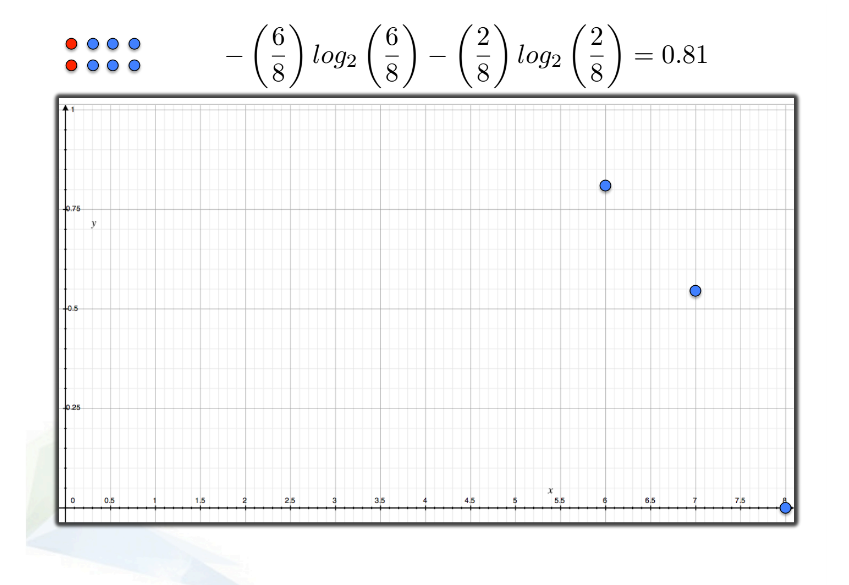

## How does a tree decide where to split?

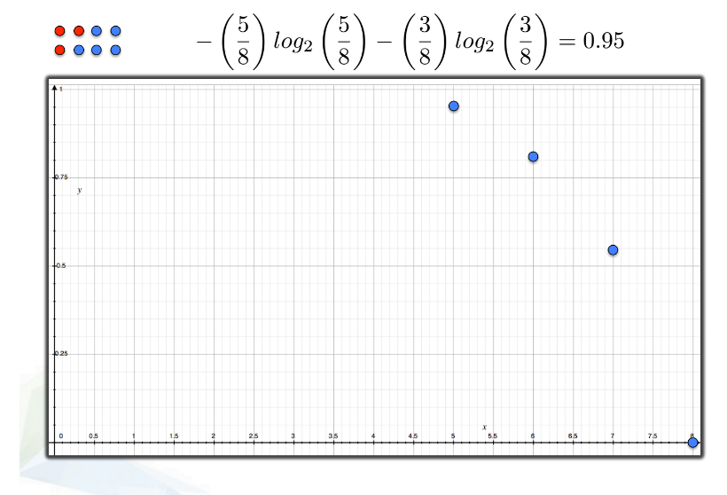

## How does a tree decide where to split?

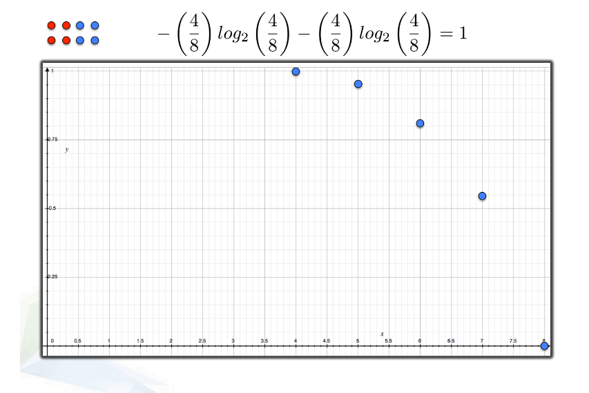

## How does a tree decide where to split?

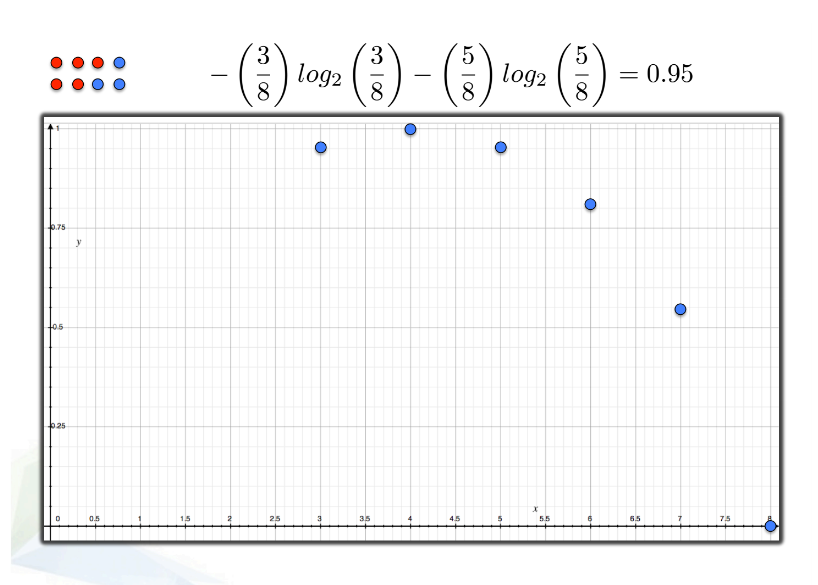

## How does a tree decide where to split?

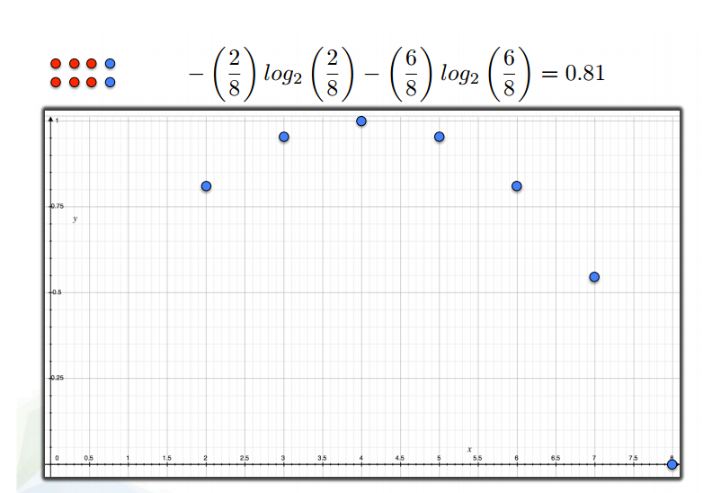

## How does a tree decide where to split?

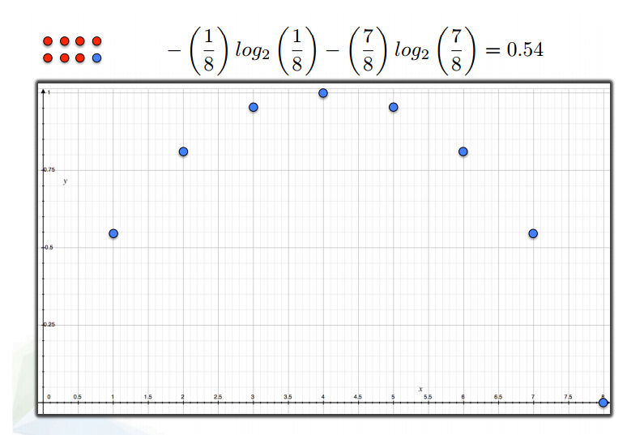

## How does a tree decide where to split?

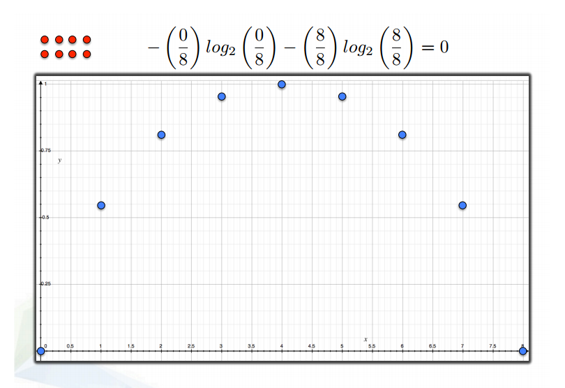

## How does a tree decide where to split?

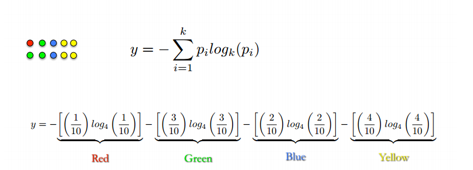

## How does a tree decide where to split?

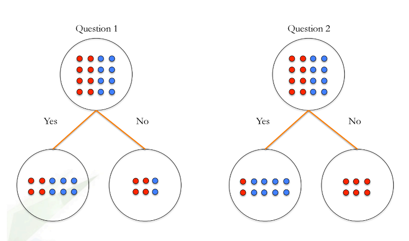

## How does a tree decide where to split?

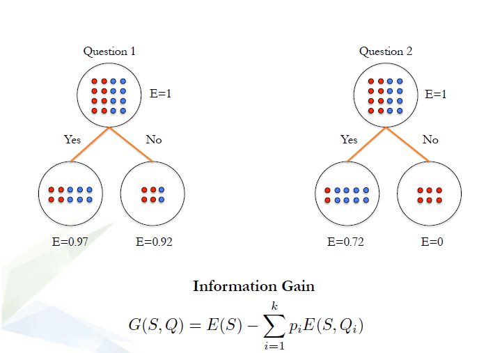

## How does a tree decide where to split?

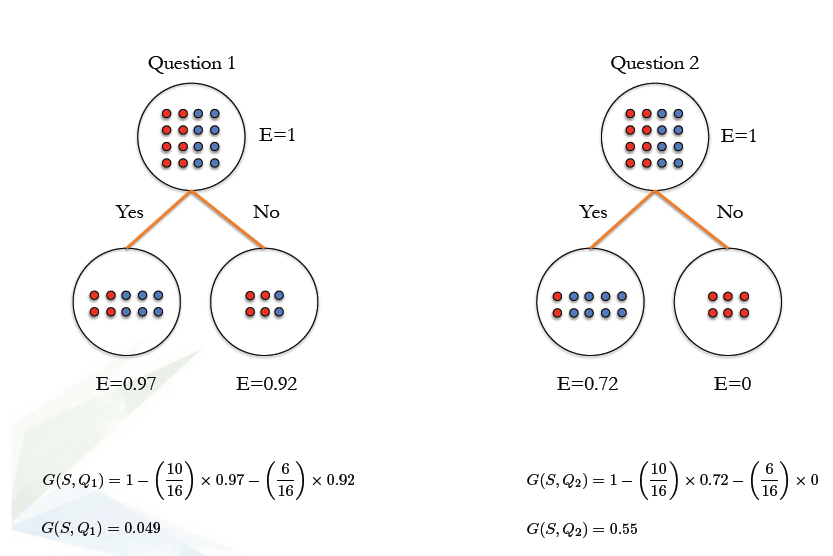

## How does a tree decide where to split?

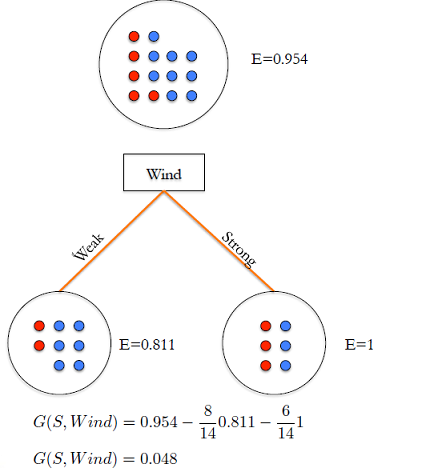

## How does a tree decide where to split?

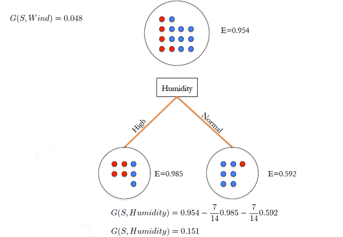

## How does a tree decide where to split?

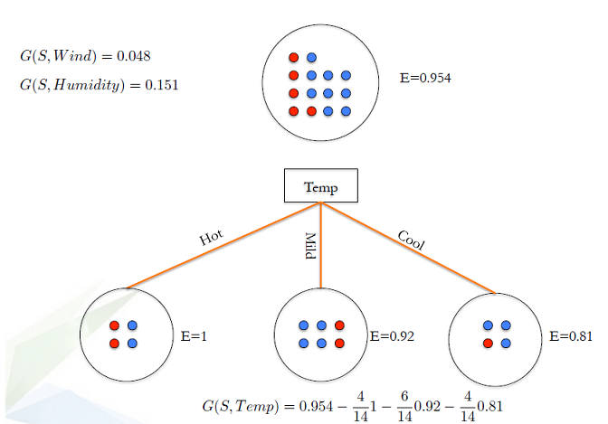

## How does a tree decide where to split?

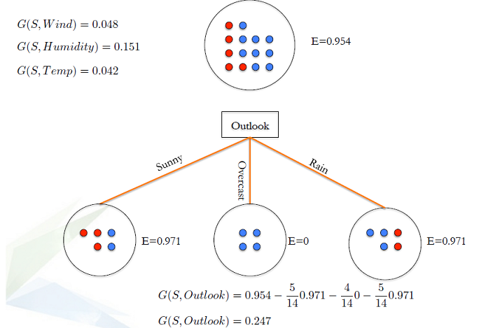

## key parameters of tree modeling

- Overfitting is one of the key challenges faced while modeling decision trees.
- If no limit set, tree give you 100% accuracy on training set
- Preventing overfitting is essential in fitting a decision tree and it can be done in 2 ways:
  - Setting constraints on tree size
  - Tree pruning

## Setting constraints on tree size

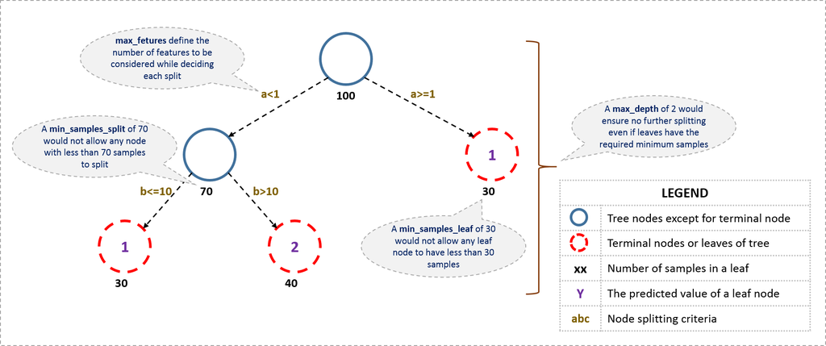

## Tree pruning

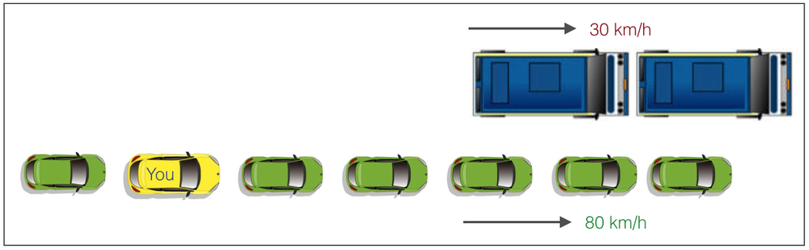

1. A lane with cars moving at 80km/h
2. A lane with trucks moving at 30km/h

At this instant, you are the yellow car and you have 2 choices:

1. Take a left and overtake the other 2 cars quickly
2. Keep moving in the present lane

## Tree pruning

1. Make the decision tree to a large depth.
2. Start at the bottom and start removing leaves which are giving us negative IG when compared from the top.

Suppose a split is giving us a gain of say -10 (loss of 10) and then the next split on that gives us a gain of 20. A simple decision tree will stop at step 1 but in pruning, we will see that the overall gain is +10 and keep both leaves.

## Are tree based models better than logistic models?

- If the relationship between dependent & independent variable is well approximated by a linear model, linear regression will outperform tree based model.
- If there is a high non-linearity & complex relationship between dependent & independent variables, a tree model will outperform a classical regression method.
- If you need to build a model which is easy to explain to people, a decision tree model will always do better than a linear model. Decision tree models are even simpler to interpret than linear regression!

## Working with decision trees in R

```r
library(rpart)
set.seed(9850)
idxr  <- runif(nrow(iris))
irisr <-iris[order(idxr),]
miris <- rpart(Species ~., data = irisr[1:100,],control = rpart.control(cp=0.005, xval=10, maxdepth=5))
miris
```

```
#> n= 100
#>
#> node), split, n, loss, yval, (yprob)
#>       * denotes terminal node
#>
#> 1) root 100 65 versicolor (0.34000000 0.35000000 0.31000000)
#>   2) Petal.Length< 2.6 34  0 setosa (1.00000000 0.00000000 0.00000000) *
#>   3) Petal.Length>=2.6 66 31 versicolor (0.00000000 0.53030303 0.46969697)
#>     6) Petal.Width< 1.65 37  2 versicolor (0.00000000 0.94594595 0.05405405) *
#>     7) Petal.Width>=1.65 29  0 virginica (0.00000000 0.00000000 1.00000000) *
```

\(cp\) is the complexity parameter, see `help(rpart.control)`

## how to read the output?

node), split, n, loss, yval, (yprob)

1. node): indicates the node number; 2. split: indicates the split criterion
2. n: indicates the number of individuals in the groupe
3. loss: indicates the the number of individuals misclassified
4. yval: indicates the predicted value
5. (yprob): indicates the probability of belonging to each class

**Note:** when you fit a tree using `rpart`, the fitting routine automatically performs `10-fold CV` and stores the errors for later use (such as for pruning the tree)

## how to read the output?

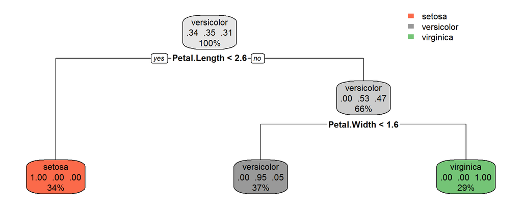

```r
library(rpart.plot)
rpart.plot(miris)
```

## how to read the output?

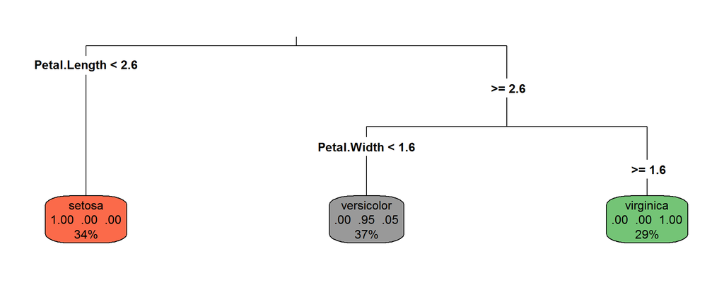

```r
rpart.plot(miris, type = 3)
```

## how to read the output?

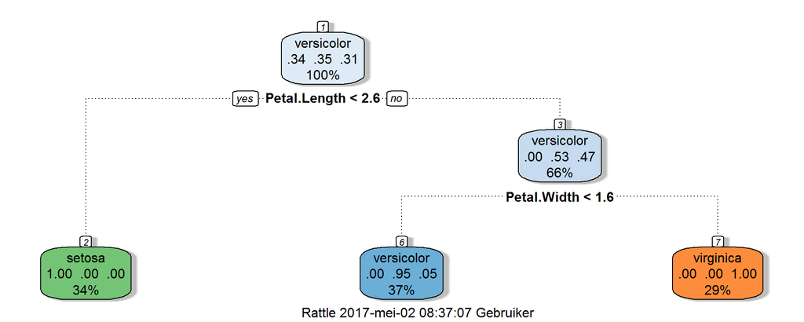

```r
library(rattle)
library(RColorBrewer)
fancyRpartPlot(miris)
```

## how to read the output?

```r
summary(miris)
```

```
#> Call:
#> rpart(formula = Species ~ ., data = irisr[1:100, ], control = rpart.control(cp = 0.005,
#>     xval = 10, maxdepth = 5))
#>   n= 100
#>
#>          CP nsplit  rel error     xerror       xstd
#> 1 0.5230769      0 1.00000000 1.20000000 0.06373020
#> 2 0.4461538      1 0.47692308 0.81538462 0.07678449
#> 3 0.0050000      2 0.03076923 0.06153846 0.03014757
#>
#> Variable importance
#>  Petal.Width Petal.Length Sepal.Length  Sepal.Width
#>           34           31           21           14
#>
#> Node number 1: 100 observations,    complexity param=0.5230769
#>   predicted class=versicolor  expected loss=0.65  P(node) =1
#>     class counts:    34    35    31
#>    probabilities: 0.340 0.350 0.310
#>   left son=2 (34 obs) right son=3 (66 obs)
#>   Primary splits:
#>       Petal.Length < 2.6  to the left,  improve=33.70121, (0 missing)
#>       Petal.Width  < 0.8  to the left,  improve=33.70121, (0 missing)
#>       Sepal.Length < 5.45 to the left,  improve=20.39105, (0 missing)
#>       Sepal.Width  < 3.05 to the right, improve=14.88870, (0 missing)
#>   Surrogate splits:
#>       Petal.Width  < 0.8  to the left,  agree=1.00, adj=1.000, (0 split)
#>       Sepal.Length < 5.35 to the left,  agree=0.90, adj=0.706, (0 split)
#>       Sepal.Width  < 3.35 to the right, agree=0.83, adj=0.500, (0 split)
#>
#> Node number 2: 34 observations
#>   predicted class=setosa      expected loss=0  P(node) =0.34
#>     class counts:    34     0     0
#>    probabilities: 1.000 0.000 0.000
#>
#> Node number 3: 66 observations,    complexity param=0.4461538
#>   predicted class=versicolor  expected loss=0.469697  P(node) =0.66
#>     class counts:     0    35    31
#>    probabilities: 0.000 0.530 0.470
#>   left son=6 (37 obs) right son=7 (29 obs)
#>   Primary splits:
#>       Petal.Width  < 1.65 to the left,  improve=29.09500, (0 missing)
#>       Petal.Length < 4.75 to the left,  improve=27.18761, (0 missing)
#>       Sepal.Length < 6.65 to the left,  improve=11.15657, (0 missing)
#>       Sepal.Width  < 2.95 to the left,  improve= 4.24345, (0 missing)
#>   Surrogate splits:
#>       Petal.Length < 4.75 to the left,  agree=0.924, adj=0.828, (0 split)
#>       Sepal.Length < 6.35 to the left,  agree=0.803, adj=0.552, (0 split)
#>       Sepal.Width  < 2.95 to the left,  agree=0.712, adj=0.345, (0 split)
#>
#> Node number 6: 37 observations
#>   predicted class=versicolor  expected loss=0.05405405  P(node) =0.37
#>     class counts:     0    35     2
#>    probabilities: 0.000 0.946 0.054
#>
#> Node number 7: 29 observations
#>   predicted class=virginica   expected loss=0  P(node) =0.29
#>     class counts:     0     0    29
#>    probabilities: 0.000 0.000 1.000
```

## Use the model to predict the class/category of new data

```r
piris <- predict(miris, irisr[101:150,], type = "class")
table(irisr[101:150,5],piris)
```

```
#>             piris
#>              setosa versicolor virginica
#>   setosa         16          0         0
#>   versicolor      0         13         2
#>   virginica       0          2        17
```